# AmpliconSeq Analysis Pipeline Package

Matt Eldridge, Cancer Research UK Cambridge Institute, University of Cambridge

### Introduction

AmpliconSeq is an analysis pipeline package that implements a workflow for calling single nucleotide variants (SNVs) and indels in targeted amplicon sequencing data. The pipeline offers a choice of variant callers, including GATK HaplotypeCaller, GATK UnifiedGenotyper, FreeBayes and VarDict, and carries out post-calling filtering to select high-confidence variants. In addition, alignment and target coverage metrics are computed and compiled into a summary report. Variants are annotated using Ensembl Variant Effect Predictor with details about consequence on protein coding, accession numbers for known variants and associated minor allele frequencies from the 1000 Genomes project.

The AmpliconSeq pipeline has the following features:

- Choice of variant callers: GATK HaplotypeCaller, GATK UnifiedGenotyper, FreeBayes and VarDict
- Alignment and coverage QC report using metrics calculated by Picard tools
- Annotation of variants using Ensembl Variant Effect Predictor
- Support for overlapping amplicon targets by partitioning reads prior to variant calling
- Support for calling and filtering low allele fraction SNVs, e.g. for circulating tumour DNA in plasma samples with allele fractions down to 0.1%, by fitting probability distributions to model background noise
- *Specific calling* of known mutations
- Support for Slurm and Platform LSF job schedulers for running on a high-performance computing cluster
- Accompanying visualization tool for viewing and assessing SNV calls

The AmpliconSeq pipeline was developed in collaboration with James Brenton’s group at Cancer Research UK Cambridge Institute, particularly with the support of Anna Piskorz, Tedi Goranova and Geoff McIntyre. The figure below is a schematic of the AmpliconSeq workflow; note that the pipeline does not peform alignment of sequences to a reference genome but this is included in the diagram to indicate that this is a necessary step in the bioinformatic analysis prior to running the pipeline.

[figure not shown]

Schematic overview of the AmpliconSeq workflow

The workflow is executed using the workflow engine developed by Richard Bowers at the Cancer Research UK Cambridge Institute (CRUK-CI) and distributes the computational workload across multiple processors either on a powerful multi-processor server or on a high-performance compute cluster.

The workflow system is a Java application that separates the mechanics of running sequences of dependent jobs from the specifics of a given pipeline specification. It offers a number of advantages for constructing pipelines including the ability to restart pipelines that fail during execution without re-running tasks that completed successfully and allowing pipelines to run on either a single multi-processor machine or a compute cluster by simply changing a run-time option. Job scheduling systems supported by the workflow engine include Platform LSF, TORQUE and SLURM. The workflow system also handles memory allocation for jobs, including setting the maximum heap size for Java programs, e.g. Picard and GATK, and can attempt to re-run jobs that fail through having insufficient memory by incrementally increasing the memory allocation up to a specified maximum value.

The workflow system defines XML schema for task definitions, pipeline construction (describing how the tasks are wired together) and also for the configuration file used for a specific workflow instance or run. Task and pipeline definitions are stored in the tasks and pipelines subdirectories respectively within the AmpliconSeq pipeline installation directory and should not normally be modified. Sample configuration files for the GATK, FreeBayes and VarDict variant callers can be found within the config subdirectory.

### Installation

#### Pre-requisites

The following software needs to be installed:

- Unix Bourne and Bash shells
- Java SE 8 or above
- Genome Analysis Toolkit (GATK) version 3.6 or above
- FreeBayes (optional)
- VarDict (Java version only, optional) version 1.4.10 or above
- R including the packages Nozzle.R1, base64, scales, forcats, tidyr, dplyr, ggplot2, fitdistrplus
- R packages shiny, DT and highcharter for R/Shiny visualization tool (optional)
- Perl
- Ensembl Variant Effect Predictor and dependent Perl packages (File::Copy::Recursive, Archive::Zip, DBI)

The workflow system on which the AmpliconSeq pipeline package is built creates shell scripts for some of the tasks so both Bourne and Bash shells need to be available.

GATK is required regardless of which variant caller has been selected as it is used in filtering variants and calculating SNV metrics.

The workflow system and GATK are both Java applications requiring a suitable Java Runtime Environment. You can test the availability and version Java of on your system using the following command:

```
java -version
```

Recent versions of the HTSJDK library and Picard tools package, including the version distributed and used in this pipeline require Java 8, i.e. version 1.8 or above when running the above command.

Support for VarDict is limited to the Java version, VarDictJava; the Perl version has not been tested. The installation directory contains scripts for postprocessing the output from VarDict taken from the VarDict GitHub repository (see the licensing section below). These have been tested with VarDictJava version 1.4.10 and may not work with earlier or later releases. These location of these scripts can be changed in the configuration file to use updated versions compatible with later releases of VarDict.

Report(s) are generated using R. The pipeline expects the Rscript executable to be available on the path and that the dependent packages listed above are pre-installed.

Ensembl Variant Effect Predictor (VEP) is used to annotate variants with the consequence on protein coding, details of known variants and associated minor allele frequencies from the 1000 Genomes project. This is run in offline mode so additionally the cache files for the reference genome against which the sequence data were aligned are required.

#### Installing the AmpliconSeq pipeline package

The AmpliconSeq pipeline is available in pre-packaged form and can be unpacked as follows (note that the version number should be substituted in the following command).

```
tar zxf ampliconseq-pipeline-X.Y-distribution.tar.gz
```

#### Installing the GATK package

The GATK package cannot be redistributed within this package under the terms of Broad Institute Software License Agreement. Instead this needs to be downloaded and unpacked separately.

By default the pipeline contained in this package is configured to use the GATK jar file called gatk.jar in the installation directory. The GATK jar file (usually named GenomeAnalysisTK.jar) can be moved or copied to the installation directory and renamed to gatk.jar. Alternatively create a symbolic link called gatk.jar to the location of the GATK jar file or configure the gatkClasspath variable within the pipeline configuration file to be the full path for the GATK jar file.

### Running the pipeline

#### Configuring the pipeline

1. Copy a sample configuration file from the config subdirectory of the AmpliconSeq installation to a working directory.
2. Modify the configuration settings as appropriate, particularly variables corresponding to input file(s). For details of the configuration options available for a pipeline, refer to the comments on each setting within the corresponding sample configuration file and see the Configuration section below.

#### Running the pipeline

Run the pipeline using the run-pipeline command within the bin subdirectory of the AmpliconSeq installation, e.g.

```
/path_to/ampliconseq/bin/run-pipeline --mode local config.xml
```

where config.xml is the configuration file and the mode option is used to instruct the workflow engine to run in local mode, i.e. not using a job scheduler. Note that the –mode command line option is not required but if set will override the value specified in the configuration file.

To run on a compute cluster using the LSF scheduler:

```
/path_to/ampliconseq/bin/run-pipeline --mode lsf config.xml
```

Similarly, to run on a compute cluster using the Slurm scheduler:

```
/path_to/ampliconseq/bin/run-pipeline --mode slurm config.xml
```

To view other options that can be specified at run-time:

```
/path_to/ampliconseq/bin/run-pipeline --help
```

### Configuration

The pipeline configuration file is an XML file in which a number of parameters or variables can be set for a given run. Examples for each variant caller supported are given in the config subdirectory. These can be copied to the run directory and modified as appropriate.

There is a comment for each setting within the configuration file that describes the purpose of that configuration variable and should help in deciding whether this needs to be set specifically for a run. An example is given below for setting the variant caller to be used.

```
        <!-- the variant caller (one of HaplotypeCaller, UnifiedGenotyper,
             FreeBayes or VarDict)
        -->
        <variantCaller>VarDict</variantCaller>
```

Configuration options relating to the run-time mode or scheduler can be found in the executionConfiguration section of the configuration file. More details are available in the comments in the sample configuration files and in the workflow system user guide (available separately).

Options that are specific to the AmpliconSeq workflow being run are defined in a variables block.

An identifier for a pipeline run must be specified in the runId variable within the configuration file, e.g.

```
    <variables>
        <runId>MDE123</runId>
        ...
    </variables>
```

This is used in creating job names and in constructing names for temporary, intermediate and final output files.

The ${…} notation is used to substitute variable values within pipeline definitions and the configuration file. For example it is possible to define variables using the values of other variables, e.g.

```
    <variables>
        <runId>MDE123</runId>
        <outputFilePrefix>${runId}.</outputFilePrefix>
        ...
    </variables>
```

The ${install} variable is a special variable that refers to the installation directory. An example of its use is in instructing the workflow engine which pipeline to run within the configuration file, e.g.

```
    <pipeline>${install}/pipelines/ampliconseq.xml</pipeline>
```

The working directory for a pipeline run is set by default to be the current working directory in which the run-pipeline command was executed using another special property, @{user.dir}

```
        <work>@{user.dir}</work>
```

### Pipeline inputs

The primary inputs to the pipeline are a sample metadata file that provides sample details for each sequencing library or dataset and a corresponding set of BAM files, containing aligned sequence reads, one for each dataset or library.

#### Samples file

The samples file associates information about each of the DNA samples with the corresponding sequencing dataset/library identifier or barcode. This is a tab-delimited file with a column containing dataset identifiers with heading ID (or one of the synonyms Barcode or Dataset ID) and any number of additional columns.

Other sample details that, if present, will be extracted and included in the variant output file, include the sample name or identifier (Sample, Sample ID or Sample name column), sample type (Sample type), and patient identifier (Patient identifier or Patient ID). Columns can be in any order and matching of column headings is case-insensitive and allows for some flexibility in terms of use of spaces or underscore characters, e.g. sample_name, SampleID, etc.

The dataset identifier or barcode usually corresponds to a single sequencing library. There may be multiple libraries for each DNA sample, as in the following example where there are duplicate libraries for each sample. Replicate libraries for a single sample are recognized by sharing a common sample name. Variant details for replicates are combined into a single row in the collated variant output files.

An example samples file containing dulicate libraries for each sample is given below.

```
ID        SAMPLE
FLD0013   JBLAB-2063
FLD0014   JBLAB-2150
FLD0015   JBLAB-2151
FLD0016   JBLAB-2137
FLD0017   JBLAB-199
FLD0037   JBLAB-2063
FLD0038   JBLAB-2150
FLD0039   JBLAB-2151
FLD0040   JBLAB-2137
FLD0041   JBLAB-199
```

The samples file is configured with the sampleSheet variable.

```
        <sampleSheet>${work}/samples.txt</sampleSheet>
```

#### BAM files

The BAM files must be contained within a single directory which is specified using the bamDir variable in the configuration file, e.g. to use the subdirectory of the current working directory named bam_files

```
        <bamDir>${work}/bam_files</bamDir>
```

See Configuration section below for more details on using variables and, specifically, the current working directory within pipelines.

The pipeline expects the BAM files to be named using the dataset identifier (or barcode) in the samples file as a prefix. For example, in the samples file given above, BAM files named FLD0013.bam, FLD0014,bam, etc. are expected.

```
        <bamSuffix>bwa.bam</bamSuffix>
```

Where BAM files do not follow the required naming scheme or are distributed across multiple directories, symbolic links can be created in another directory to avoid moving or renaming files.

Dataset identifiers are used in the naming of intermediate and output files and for jobs created and run by the workflow manager.

#### Target and amplicon intervals files

Two interval files are required, one specifying the locations of the amplicons, the other containing the location of the target within each amplicon (i.e. without the ends corresponding to primer sequences).

These must be in Picard-style interval format and should contain unique identifiers for each target amplicon. The following is an excerpt from an example amplicon file.

```
@SQ SN:chr17  LN:81195210
chr17 7572850 7573030 + TP53_E00001757276_1
chr17 7573859 7574054 + TP53_E00001728015_1
```

Each target amplicon should be represented once in the targets file and once in the amplicons file using the same identifier, so the targets corresponding to the amplicons in the previous example might be as follows.

```
@SQ SN:chr17  LN:81195210
chr17 7572870 7573010 + TP53_E00001757276_1
chr17 7573881 7574036 + TP53_E00001728015_1
```

The target and amplicon intervals files are configured with the targetIntervals and ampliconIntervals variables.

```
        <ampliconIntervals>${work}/amplicons.txt</ampliconIntervals>

        <targetIntervals>${work}/targets.txt</targetIntervals>
```

#### Reference data

The reference genome sequence file needs to be specified using the referenceSequence variable. This should be an indexed FASTA file.

```
        <referenceSequence>/reference_data/GRCh37.fa</referenceSequence>
```

Similarly there a number of variables for setting the location of the Ensembl VEP cache that will need to be configured.

```
        <!-- the offline cache directory used by Ensembl Variant Effect
             Predictor
        -->
        <variantEffectPredictorCacheDirectory>~/.vep</variantEffectPredictorCacheDirectory>

        <!-- the species annotation data to be used by Ensembl Variant Effect
             Predictor
        -->
        <variantEffectPredictorSpecies>homo_sapiens</variantEffectPredictorSpecies>

        <!-- the genome assembly to be used by Ensembl Variant Effect Predictor
        -->
        <variantEffectPredictorAssembly>GRCh37</variantEffectPredictorAssembly>

        <!-- the reference sequence FASTA file used by Ensembl Variant Effect
             Predictor
        -->
        <variantEffectPredictorReferenceSequence>${referenceSequence}</variantEffectPredictorReferenceSequence>
```

In the above, Ensembl VEP is configured to use the same reference sequence file as previously specified for use by other tasks in the pipeline. If using a different version of the reference genome to that used by Ensembl, e.g. one that uses UCSC-style naming of chromosomes (chrM, chr1, chr2, etc.) then the variantEffectPredictorReferenceSequence should be set to the version downloaded from Ensembl as part of the VEP cache to avoid some issues with HGVS annotations affecting the cDNA and protein effect columns in the output variant spreadsheet.

#### Optional inputs

There are a number of optional input files relating to specific calling of known variants, blacklisting variants and specifying which SNVs to use in creating an allele fraction table. More details are given in the Notes section below.

### Pipeline outputs

The pipeline produces separate SNV and indel VCF files for each dataset along with alignment summary and target coverage metrics files, including an HTML report. The SNV and indel calls are collated for all datasets in which details for replicates for each sample are combined into a single entry or row that also includes annotations from Ensembl Variant Effect Predictor; these collated results are produced as both tab-separated text files and an Excel spreadsheet.

Output files can be written to a specific directory by setting the outputDir variable and can be given a prefix using the outputFilePrefix variable. Note that a separator character (‘.’) is not added after the prefix when constructing output file names so should be added if required; this allows for prefixes of the form ’${runId}_’.

For example to prefix all output files with the run identifier, set the outputFilePrefix variable as follows.

```
        <outputFilePrefix>${runId}.</outputFilePrefix>
```

See the Configuration section below for more details on the run identifier.

The following are the main outputs of the AmpliconSeq pipeline (note that the file names may be prefixed as described above).

| File | Description |
| --- | --- |
| alignment_coverage_report.html | HTML report containing alignment summary metrics and target coverage metrics |
| amplicon_coverage.xlsx | Excel spreadsheet containing coverage for each library and amplicon pairing |
| read_counts.txt | Table of read counts for each base at every target position for all libraries |
| snv.txt | Collated SNV calls for all sample/patient replicate libraries |
| snv.filtered.txt | Filtered SNV calls that exclude low-confidence calls not marked for specific calling |
| snv_allele_fraction.xlsx | Excel spreadsheet containing allele fractions for selected SNVs |
| indel.txt | Collated indel calls for all sample/patient replicate libraries |
| indel.filtered.txt | Filtered indel calls that exclude low-confidence calls not marked for specific calling |
| variants.xlsx | Excel spreadsheet containing collated, filtered SNV and indel calls |

#### Variants tables

The variants.xlsx Excel spreadsheet is the principal output from the pipeline and includes two tables for the SNV and indel calls.

In creating this spreadsheet, variants from the VCF files (see below) are collated for all libraries along with Ensembl VEP annotations into the snv.txt and indel.txt tab-delimited files.

These are then filtered to exclude low-confidence and blacklisted variants that have not been listed for specific calling and blacklisted variants to create the snv.filtered.txt and indel.filtered.txt tab-delimited files, from which the spreadsheet is created.

The SNV tabular files, snv.txt and snv.filtered.txt, can be read into the visualization tool packaged with this pipeline (see the section on low allele fraction SNVs below for more details).

#### VCF files

The pipeline generates indexed SNV and indel VCF files for each library which can amount to a large number of files. The output directory for these VCF files defaults to a subdirectory named vcf within the output directory (specified using the outputDir variable) but can be configured to be a different directory using the outputVcfDir variable.

#### Coverage table

In addition the alignment and coverage HTML report, an Excel spreadsheet is generated that contains the mean depth covered by each amplicon within each dataset in tabular form. This uses conditional formatting to highlight library/amplicon pairs with low coverage; the coverageThreshold setting is used to set a threshold below which depth of coverage will be highlighted.

#### SNV allele fraction table

Allele fractions for a predetermined set of SNVs are calculated and can help in identifying sample swaps. A tab-delimited file containing the SNVs to be used can be specified by configuring the snvsForAlleleFractionTable variable (see note below). If this is not specified the union of all medium and high-confidence SNVs called in all samples is used.

Where replicate libraries for samples have been included in the run, those SNVs where there is a substantial difference in the allele fractions between replicates are highlighted and the number of SNVs flagged are tabulated in the Flagged column. The maximum tolerated difference in allele fraction can be set using the maxAlleleFractionDifference configuration variable.

#### Read counts file

The read counts file contains the number of reads for every allele at each target location. This is used in modelling the background noise and filtering of SNV calls, particularly for low-frequency calling.

The read counts file is also used for depth and allele fraction estimates where these are not given by the variant caller, e.g. for specific calling of SNVs that were not called.

The visualization tool uses the read counts file to display scatter plots of allele fractions for selected SNVs or any given substitution to help with assessment of whether a variant is real (see the section on low allele fraction SNVs below for more details).

The way in which overlapping read pairs contribute to allele counts can be configured using the countOverlappingReadPairsMode setting, including how to handle positions where the base called in the two reads disagree. Other configuration settings for the calculation of allele read counts and SNV metrics are available, including minimum mapping and base qualities; see the sample configuration file(s) for details.

### Notes

#### Replicate libraries for each sample

The annotated variant output file contains a single row for each variant within each sample in which the details for each replicate are collated, i.e. each row contains multiple columns for the quality, depth and allele fraction for each replicate library. The number of columns for each of these values depends on the maximum number of replicates for any sample. There is a potential issue with this if there are a larger number of replicates for control samples, e.g. water. To avoid an ungainly output file the control libraries can be given different sample names in the samples file, e.g.

```
ID       SAMPLE
FLD0336  NTC1(water)
FLD0048  NTC2(water)
FLD0072  NTC3(water)
FLD0024  NTC4(water)
FLD0096  NTC5(water)
FLD0312  NTC6(water)
```

#### Filters

SNV and indel filtering is carried out using the GATK VariantFiltration tool. Filters are specified using the snvFilterExpression and indelFilterExpression variables and take the form of logical expressions. Multiple filters can be applied in a comma-separated list.

There are also snvFilterName and indelFilterName variables that give names to each of the filter expressions; these names are included in the output VCF files and are the names used in the filter columns of the output variant spreadsheet.

An example configuration of filters for the GATK variant callers is given below. The attributes used in these expressions, e.g. QD, FD, MQ, etc., are values computed by the variant caller and contained in the VCF file, or can be additional metrics computed by the pipeline and added to the VCF file.

```
        <!-- the names of filters used in selecting high confidence SNV calls;
             can contain multiple filter names in a comma-separated list where
             each has a corresponding filter expression in the
             snvFilterExpression variable
        -->
        <snvFilterName>QD,FS,MQ,MQRankSum,PositionNoise,DatasetNoise</snvFilterName>

        <!-- the filter expression to use for selecting high confidence SNV
             calls; can contain multiple expressions in a comma-separated list
             where each has a corresponding name in the snvFilterName variable
        -->
        <snvFilterExpression><![CDATA[QD < 2.0,FS > 60.0,MQ < 40.0,MQRankSum < -12.5,VariantAlleleFraction < PositionSubstitutionAFThreshold,VariantAlleleFraction < DatasetSubstitutionAFThreshold]]></snvFilterExpression>

        <!-- the names of filters used in selecting high confidence indel calls;
             can contain multiple filter names in a comma-separated list where
             each has a corresponding filter expression in the
             indelFilterExpression variable
        -->
        <indelFilterName>QD,FS</indelFilterName>

        <!-- the filter expression to use for selecting high confidence indel
             calls; can contain multiple expressions in a comma-separated list
             where each has a corresponding name in the indelFilterName variable
        -->
        <indelFilterExpression><![CDATA[QD < 2.0,FS > 200.0]]></indelFilterExpression>
```

There should be an equal number of names and expressions in the snvFilterName and snvFilterExpression variables, similarly an equal number in the indelFilterName and indelFilterExpression variables.

Note that the <[CDATA[…]]> construct is used to allow characters such as ‘<’ and ‘>’ within filter expressions that would otherwise be interpreted as opening or closing elements as part of the XML syntax.

Filters are specified using Java Expression Language (JEXL) syntax in the snvFilterExpression and indelFilterExpression variables. See the GATK documentation for more details about using JEXL expressions for filtering variants.

#### Confidence level for variants called in replicate libraries

The variants in the collated variant output files are given a confidence level that can be high, medium or low. Factors in determining the confidence include the number of replicates in which the call is made without being filtered and whether a minimum depth threshold was reached for the replicate library in order to make the call. The depth or coverage threshold is specified in the configuration file using the coverageThreshold variable; by default this is set to 100.

| Confidence | Criteria |
| --- | --- |
| High | Call passes filters in all replicates and depth in each is not below the minimum coverage threshold. |
| Medium | Call passes filters in at least one replicate with a depth that is not below the minimum coverage threshold. |
| Low | Calls which don’t pass filters in any replicate or for which there is insufficient coverage. |

Low-confidence variants are excluded from the variant spreadsheet, variants.xlsx file, unless listed for specific calling. The tab-delimited files snv.txt and indel.txt include all variants called including those with low confidence.

#### Depths and allele fractions

Depths and allele fractions for variants called in one or more but not all replicates are included in the output variant tables but where a call was not made these are computed from the read counts that are generated using GATK. For replicates for which a call is made, depths and allele fractions will preferentially be taken from the VCF file output by the variant caller. If the variant caller doesn’t call the variant for a replicate or doesn’t output the depth or allele fraction for a call, the values included in the final variants table will instead be those computed from the read counts.

#### Specific variant calling

There is support for “specific calling” for SNVs, i.e. the depth and allele fraction for specified SNVs will be included in the output variant spreadsheet regardless of whether those variants were called or filtered as low-confidence calls. This is potentially useful for longitudinal tracking of patient samples in which the allele fractions of known mutations can be monitored over time.

A tabular file containing variants for specific calling can be configured by setting the specificCallingVariants variable. If specific calling is not required this variable can be left unset.

```
        <specificCallingVariants>${work}/known_variants.txt</specificCallingVariants>
```

The file should be tab-delimited and contain columns for the sample, chromosome, position, reference base and alternate allele as shown in the following example.

```
Sample   Chromosome  Position  Ref  Alt
mde1012  chr17       7577538   C    T
mde1025  chr17       7577594   A    T
mde1079  chr17       7577538   C    T
mde1200  chr17       7578406   C    T
```

The output variant spreadsheet, variants.xlsx, includes a column called Specific that allows for filtering within Excel of the variants specified for specific calling.

In the current release there is only limited support for specific calling of indels. If indels are included in the specificCallingVariants file, these will be included in the indels worksheet in the variants spreadsheet with a “yes” in the Specific column and Ensembl VEP annotations but depth and allele fractions will only be available if the indel was called.

#### Blacklisting variants

For some target amplicon panels it may be desirable to blacklist certain variants, e.g. where those variants are very common in the population at large. This can be done by creating a 4-column tab-delimited file with columns for the chromosome, position, reference base and alternate allele.

The blacklist file is configured by setting the blacklistedVariants variable. If blacklisting is not needed this variable can be left unset.

```
        <blacklistedVariants>${work}/blacklist.txt</blacklistedVariants>
```

Both SNVs and indels can be included in the blacklist file, an example of which is given below.

```
Chromosome  Position  Ref  Alt
chr17       7577644   C    G
chr17       7578210   T    C
chr17       7579472   G    C
chr17       7579920   A    AC
```

Variants in the blacklist are excluded from the final variants spreadsheet unless these have also been specified for specific calling.

#### SNV allele fraction table for identifying sample swaps

The SNV allele fraction spreadsheet can help in identifying possible sample swaps. This contains allele fractions for every sample for a predetermined set of SNVs, for example common SNPs from the 1000 Genomes project lying within the target amplicons.

The SNV file is configured by setting the snvsForAlleleFractionTable variable and is a tab-delimited file containing 4 columns for the chromosome, position, reference base and alternate allele.

```
        <snvsForAlleleFractionTable>${work}/1000_genomes_snps.txt</snvsForAlleleFractionTable>
```

The following snippet shows the format of the SNV file.

```
Chromosome  Position  Ref  Alt
chr7        55248926  T    C
chr7        55248930  C    T
chr7        55248965  C    T
chr7        55248991  C    G
chr7        55249063  G    A
```

Allele fractions are computed using GATK and may differ from the allele fractions computed by the variant caller; note that the variant caller will not necessarily call the selected SNVs for which allele fractions are to be calculated.

Potential sample swaps may be indicated if there are several sizeable differences in the allele fractions between pairs of sample replicates. The variant allele fraction is highlighted if it differs from that for a replicate by more than a tolerated amount specified using the maxAlleleFractionDifference setting and where the depth is above a minimum value specified with the coverageThreshold variable.

#### Differing depths reported by various tools within the pipeline

Three different measures of the depth of sequencing are reported in the various output files for this pipeline.

The Picard CollectTargetedPcrMetrics tool gives the mean target coverage for each amplicon target region defined in the targets file (see above). The depth computed by Picard is given in the target coverage output file and used in the HTML report.

The pipeline segregates reads by the target amplicon and, depending on the settings for the maximum distance of the alignment start or end position to the amplicon start or end position (maxDistanceFromAmpliconEnd setting), i.e. how close the alignment has to be to the expected location of reads, and whether both ends of a read pair need to be anchored within this distance (requireBothEndsAnchored setting), the depth computed will be lower than that given by Picard. In addition, where there are overlapping amplicons Picard will count the reads in the overlapping region twice when calculating the average depth for each of the overlapping amplicon. The depth given in the amplicon coverage file and spreadsheet is that computed for reads assigned to each amplicon separately.

Finally, the depths reported in the collated variant output file(s) are taken from the VCF files produced by the variant caller. Depending on the variant caller, these may be the number of reads used to call variants and may exclude reads filtered because of low mapping quality or base quality at the variant position.

Generally, the depth from the Picard metrics will be higher than the depth computed by the pipeline for reads assigned to separate amplicons, and this will likely be higher than the number of reads used to call variants.

### Low allele fraction SNVs

The AmpliconSeq pipeline supports calling of SNVs with low allele fractions through modelling the background noise in the sequence data. This allows for calling SNVs from circulating tumour DNA in plasma samples with allele fractions as low as 0.1%, although this is only possible for certain substitution types in which the background noise levels are low. For example, with Illumina sequencers C>G, G>C, A>C and T>G variants are more amenable to calling at low allele fractions than A>G, T>C, C>T and G>A.

FreeBayes and VarDict can call variants with very low allele fractions by setting the minimumAlleleFraction configuration variable, e.g. to 0.1% as shown below. The GATK variant callers do not call variants with allele fractions below around 10 - 15%.

```
        <!-- the minimum allele fraction for calling variants
             (applies to FreeBayes and VarDict)
        -->
        <minimumAlleleFraction>0.001</minimumAlleleFraction>
```

#### Background noise filters

A Beta probability distribution is fitted to the distribution of allele fractions for all datasets in the run at each target position and for each of the three possible substitutions at that position. This is used to derive an allele fraction threshold below which there would be low confidence in a SNV call, using the quantile corresponding to probability, p = 0.9999. Fitting the distribution for each amplicon target position takes account of both the background noise associated with the substitution type and the position within the amplicon, in effect identifying and accounting for noisy positions.

The allele fraction threshold is added to the VCF file and then can be used during filtering by adding a filter expression as shown in the following snippet from the configuration file. Note that there would usually be other filters; see the Filters sections above for more details.

```
        <!-- the names of filters used in selecting high confidence SNV calls;
             can contain multiple filter names in a comma-separated list where
             each has a corresponding filter expression in the
             snvFilterExpression variable
        -->
        <snvFilterName>PositionNoise</snvFilterName>

        <!-- the filter expression to use for selecting high confidence SNV
             calls; can contain multiple expressions in a comma-separated list
             where each has a corresponding name in the snvFilterName variable
        -->
        <snvFilterExpression><![CDATA[VariantAlleleFraction < PositionSubstitutionAFThreshold,]]></snvFilterExpression>
```

Similarly, probability distributions are fitted separately for each substitution type within each sample dataset using all positions for which that substitution is possible. This models the background noise at the library/dataset level, so higher allele fraction thresholds are obtained for noisy libraries.

The sample configuration files provided in the pipeline distribution in the config subdirectory contain filter expressions that are suitable for each of supported variant callers and include position and dataset filters.

#### R/Shiny visualization tool

The AmpliconSeq package contains a visualization tool written in R and using the Shiny framework. To start the application, navigate on the command line to the R/shiny subdirectory within the installation and run the following.

```
Rscript start_shiny_server.R
```

This should open the application within a web browser. Brief instructions for using the applications are given below.

*Warning:* this application should be considered to a beta release and occasionally freezes, in which case either the web page should be refreshed and the data reloaded or, failing that, the application may need to be restarted.

1. From the *Read counts* tab, load the read counts file, read_counts.txt (with specified prefix), produced as one of the output files by the AmpliconSeq pipeline. The read counts file is large and it can take a few seconds before the table is populated.
2. From the *Locations* tab, select a target position and alternate allele to show the allele fractions for all libraries/datasets within the run as a scatter plot. If there are multiple overlapping target amplicons at that position these are selected using a drop down menu and viewed separately. Superimposed on the scatter plot is a box and whiskers plot. The allele fraction threshold below which SNV calls should be filtered is shown as a red line.

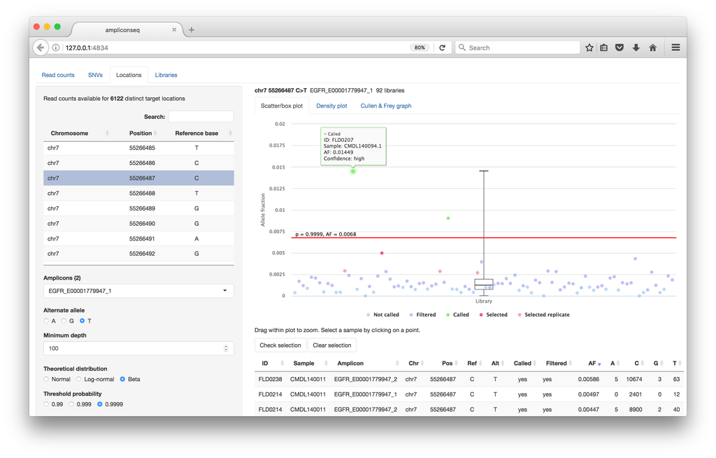

Allele fraction scatter plot for a selected position and substitution for all library datasets within a pipeline run

3. Within the *Locations* tab, select the *Density plot* tab to view the allele fractions in the form of a kernel density plot. Some filtering of the data points with the highest allele fractions and those with values of zero is performed to aid with the fitting of a probability distribution. This filtered density is also shown as well as the fitted probability distribution. The parameters for filtering data points to exclude from fitting can be modified using the dialog on the left hand side. Also, there is a choice of probability distribution that can be fitted with the Normal, Log Normal and Beta distributions available.

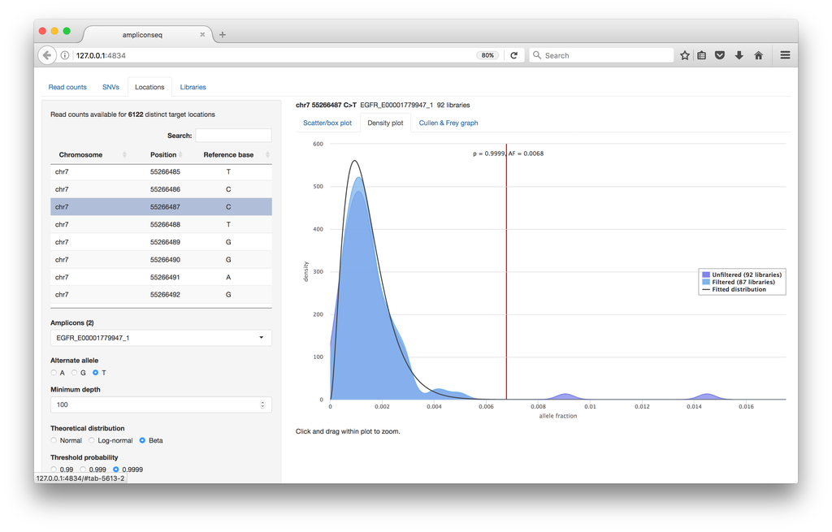

Density plot showing the distribution of allele fractions for a selected position and substitution for all library datasets within a pipeline run

4. The *Cullen and Frey* graph shows the degree of kurtosis and skewness for the allele fractions for the selected position and substitution in the context of a number of theoretical distributions. In most cases, the beta distribution seems a good choice and is the distribution used in fitting by the AmpliconSeq pipeline.

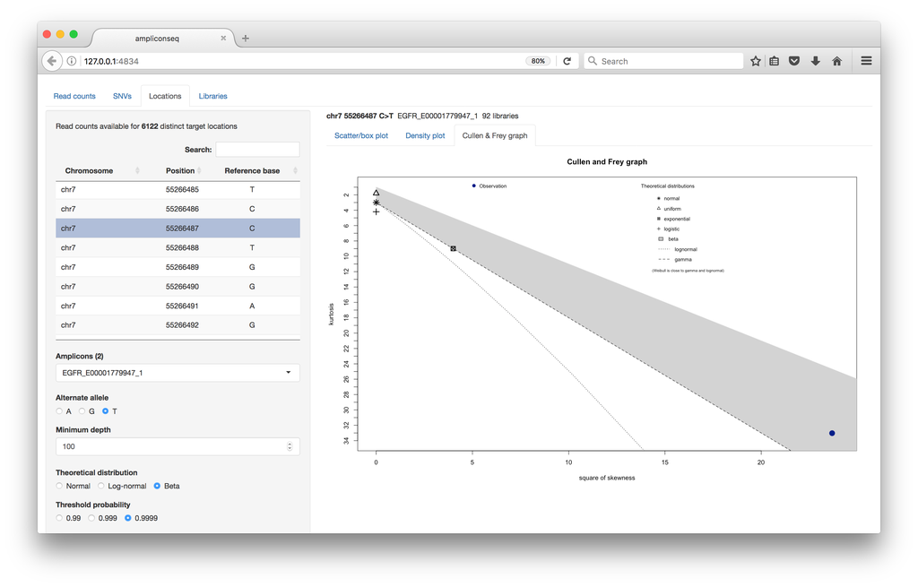

Cullen and Frey graph

5. The scatter and density plots are interactive, supporting zooming, selection of data points and display of tooltips that provide a summary for each data point. Selecting a data point provides details about the substitution in a table below the scatter plot. When SNV calls are also loaded (see below) the points in the scatter plot are categorized according to call status; clicking on the category in the legend toggles the display of points within that category.
6. From the *SNVs* tab, load the SNVs called by the AmpliconSeq pipeline. Either the full set of SNV calls (snv.txt) or the filtered calls (snv.filtered.txt) that are included in the final variants spreadsheet can be loaded. The table is populated with details of the SNV calls including the filters, if any, that were applied and the confidence of the call. The table is interactive and supports sorting by clicking on a column and filtering using the search box above the table or the individual column search boxes below the table. Selecting a SNV call in this table will update the selections in the Locations and Libraries tabs.

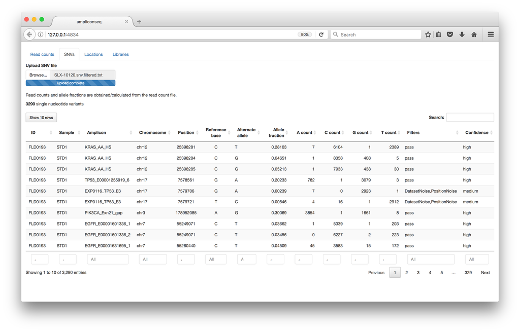

SNV table

7. The *Libraries* tab is very similar to the *Locations* tab but shows the allele fractions for all substitutions within a selected library/dataset.

### Useful links

[Genome Analysis Toolkit (GATK)](https://www.broadinstitute.org/gatk)

[FreeBayes](https://github.com/ekg/freebayes)

[VarDict](https://github.com/AstraZeneca-NGS/VarDictJava)

### License

The AmpliconSeq pipeline is made available under the MIT License (see separate LICENSE file).

##### VarDict copyright and license

The scripts teststrandbias.R and var2vcf_valid.pl from the VarDict package are redistributed in the scripts subdirectory under the MIT license (see LICENSE.VarDict in the licenses subdirectory).

##### Highcharts license

The visualization tool uses the Highcharts JavaScript library via the highcharter R package. This is free for non-profit organizations. For commercial use, licensing terms and conditions can be found at www.highcharts.com.